# Final Project

2026-10-26

```r
# install.packages("tidyverse")   # run once in the console if tidyverse is not installed; left commented so the notebook knits
library(tidyverse)
```

```r
library(ggplot2)
```

# Research question

Research question: Across mammals, does adult body length predict maximum longevity, and do primates and carnivores differ in maximum longevity, even when body length is taken into account?

# Dataset background and limitations

Original sources:

- PanTHERIA: Jones, K. E., et al. (2009). PanTHERIA: a species-level database of life history, ecology, and geography of extant and recently extinct mammals. *Ecology*, 90(9), 2648.
- AnAge: Tacutu, R., et al. (2018). Human Ageing Genomic Resources: new and updated databases. *Nucleic Acids Research*, 46(D1), D1083–D1090. https://genomics.senescence.info/species/

# Part 1: Data wrangling (Week 3)

## Task 1: Filter and select

Initial research question (Week 3, Muridae subset): Within the rodent family Muridae, how do body mass-to-length proportions scale across genera, and does increased body mass correlate with longer gestation periods or mid-range latitude?

in the code below, I am writing a csv from the PanTheria open-source dataset, which has morphological and life history parameters for thousands of species. I view to make sure it loaded in correctly I then subset. subset of rows selected: only those of family muridae (13%; reduces 5400 rows to 700). relevant columns: species, Genus, adult body mass, adult body length including head, gestation length, midrange latitude. Removing any rows with “NA” in any of these columns to get a subset of the data that has no missing values and is workable. I view to make sure everything looks correct.

```r
url <- "https://raw.githubusercontent.com/pedroj/Megafauna/master/datasets/PanTHERIA_1-0_WR05_Aug2008.txt"
pantheria_data <- read.delim(url, header = TRUE, sep = "\t", na.strings = "-999")
write.csv(pantheria_data, "PanTheria_WR05_mammals.csv", row.names = FALSE)
print("csv file has been created in working directory")
```

```
## [1] "csv file has been created in working directory"
```

```r
# View(pantheria_data)
cleaned_pantheria <-
  pantheria_data %>%
  select(MSW05_Family, MSW05_Genus, MSW05_Species, X5.1_AdultBodyMass_g, X13.1_AdultHeadBodyLen_mm, X9.1_GestationLen_d, X26.4_GR_MidRangeLat_dd) %>%
  filter(MSW05_Family == "Muridae", X5.1_AdultBodyMass_g != "NA", X13.1_AdultHeadBodyLen_mm != "NA", X9.1_GestationLen_d != "NA", X26.4_GR_MidRangeLat_dd != "NA")
# View(cleaned_pantheria)
```

## Task 2: mutate()

taking the ratio of body mass to body length at adulthood and using mutate to add this on as a column on the end of the dataset. The larger the number, the more mass the animal has relative to its body length. I then view to make sure this happened correctly

```r
mutated_pantheria <- cleaned_pantheria %>%
mutate(BodyMassLenRatio = X5.1_AdultBodyMass_g / X13.1_AdultHeadBodyLen_mm)
# View(mutated_pantheria)
```

## Task 3: group_by() and summarize()

I decided to group by genus, to see how shared evolutionary history might affect body mass, body mass to length ratio, gestation length, and midrange latitude. I am putting this into a new df called genus_summaries and then viewing it.

```r
genus_summaries <-
mutated_pantheria %>%
  group_by(MSW05_Genus) %>%
  summarize(
    n_species = n(),
    mean_body_mass  = mean(X5.1_AdultBodyMass_g),
    mean_body_mass_length_ratio = mean(BodyMassLenRatio),
    mean_gestation_length = mean(X9.1_GestationLen_d),
    mean_midrange_latitude = mean(X26.4_GR_MidRangeLat_dd),
  )
# View(genus_summaries)
```

## Task 4: Joins

using AnAge database, which examines different markers of animal aging across species. in the code blocks below, I first load in the anage csv and view it. I then make sure that the columns I want to join by, species and genus, agree with each other across datasets by renaming the columns of mutated_pantheria MSW05_Genus and MSW05_Species to Genus and Species and putting this into a new df, mutated_renamed_pantheria. Finally, I join anage and mutated_renamed_pantheria under agingpantheria, and write this into a csv.

```r
anage_url <- "https://gist.githubusercontent.com/Audree/4ef1ebd18ed0d9e9f5a5/raw/"
anage <- read_csv(anage_url)
# View(anage)
```

```r
mutated_renamed_pantheria <- mutated_pantheria %>%
rename(Genus = MSW05_Genus)%>%
rename(Species = MSW05_Species)
```

```r
agingpantheria <- mutated_renamed_pantheria %>%
  inner_join(anage, by = c("Genus", "Species"))

# View(agingpantheria)

write_csv(agingpantheria, "muridae_pantheria_anage_joined.csv")
glimpse(agingpantheria)
```

```
## Rows: 13
## Columns: 22
## $ MSW05_Family                  <chr> "Muridae", "Muridae", "Muridae", "Murida…
## $ Genus                         <chr> "Gerbillus", "Hydromys", "Meriones", "Le…
## $ Species                       <chr> "pyramidum", "chrysogaster", "unguiculat…
## $ X5.1_AdultBodyMass_g          <dbl> 42.80, 626.17, 57.75, 328.82, 69.94, 6.9…
## $ X13.1_AdultHeadBodyLen_mm     <dbl> 101.71, 275.52, 112.50, 192.73, 150.00, …
## $ X9.1_GestationLen_d           <dbl> 22.14, 36.60, 25.09, 43.49, 23.50, 21.00…
## $ X26.4_GR_MidRangeLat_dd       <dbl> 25.00, -22.13, 45.12, -30.53, 26.76, 43.…
## $ BodyMassLenRatio              <dbl> 0.4208042, 2.2726844, 0.5133333, 1.70611…
## $ HAGRID                        <dbl> 3412, 3414, 3431, 3422, 3425, 3437, 3464…
## $ Kingdom                       <chr> "Animalia", "Animalia", "Animalia", "Ani…
## $ Phylum                        <chr> "Chordata", "Chordata", "Chordata", "Cho…
## $ Class                         <chr> "Mammalia", "Mammalia", "Mammalia", "Mam…
## $ Order                         <chr> "Rodentia", "Rodentia", "Rodentia", "Rod…
## $ Family                        <chr> "Muridae", "Muridae", "Muridae", "Murida…
## $ `Common name`                 <chr> "Greater Egyptian gerbil", "Golden-belli…
## $ `Female maturity (days)`      <dbl> 74, 163, 43, 227, 61, 40, 75, 73, 82, 14…
## $ `Male maturity (days)`        <dbl> 73, 135, 36, 240, 82, 37, 75, 90, 75, 18…
## $ `Gestation/Incubation (days)` <dbl> 21, 36, 25, 38, 22, 20, 35, 37, 24, 31, …
## $ `Maximum longevity (yrs)`     <dbl> 8.2, 7.3, 6.3, 5.3, 5.6, 3.8, 6.4, 5.3, …
## $ `Specimen origin`             <chr> "captivity", "captivity", "captivity", "…
## $ `Sample size`                 <chr> "small", "medium", "medium", "small", "s…
## $ `Data quality`                <chr> "acceptable", "acceptable", "acceptable"…
```

## Written note

I chose PanTheria and Anage, open source datasets examining different morphological and life history metrics across thousands of species. I sourced the actual data from Github URLs, which are copies of the original PanTheria (Jones et al. 2009) and AnAge (Human Ageing Genomic Resources) databases.

in order to join the datasets in task 4, i had to make sure that the column names were the same so that they could be recognized across both datasets.

# Part 2: Descriptive statistics (Week 4)

After week 3, I broadened my analysis from Muridae to all mammals in the joined dataset, and shifted my focus to maximum longevity. In the code below, I re-load PanTheria without the Muridae filter, join it with AnAge, and write the result to “pantheria_anage_joined.csv”, which I use for the rest of the project.

```r
url <- "https://raw.githubusercontent.com/pedroj/Megafauna/master/datasets/PanTHERIA_1-0_WR05_Aug2008.txt"
pantheria_data <- read.delim(url, header = TRUE, sep = "\t", na.strings = "-999")
write.csv(pantheria_data, "PanTheria_WR05_mammals.csv", row.names = FALSE)
cleaned_pantheria <-
  pantheria_data %>%
  select(MSW05_Genus, MSW05_Species, X5.1_AdultBodyMass_g, X13.1_AdultHeadBodyLen_mm, X9.1_GestationLen_d, X26.4_GR_MidRangeLat_dd) %>%
  filter(X5.1_AdultBodyMass_g != "NA", X13.1_AdultHeadBodyLen_mm != "NA", X9.1_GestationLen_d != "NA", X26.4_GR_MidRangeLat_dd != "NA")
# View(cleaned_pantheria)
```

```r
anage_url <- "https://gist.githubusercontent.com/Audree/4ef1ebd18ed0d9e9f5a5/raw/"
anage <- read_csv(anage_url)
# View(anage)
```

```r
renamed_pantheria <- cleaned_pantheria %>%
rename(Genus = MSW05_Genus)%>%
rename(Species = MSW05_Species)

agingpantheria <- renamed_pantheria %>%
  inner_join(anage, by = c("Genus", "Species"))

# move the taxonomy columns to the front, from broadest to most specific
agingpantheria <- agingpantheria %>% relocate(Kingdom, Phylum, Class, Order, Family, Genus, Species)

# View(agingpantheria)

write_csv(agingpantheria, "pantheria_anage_joined.csv")
```

## Task 1: Describe a categorical variable

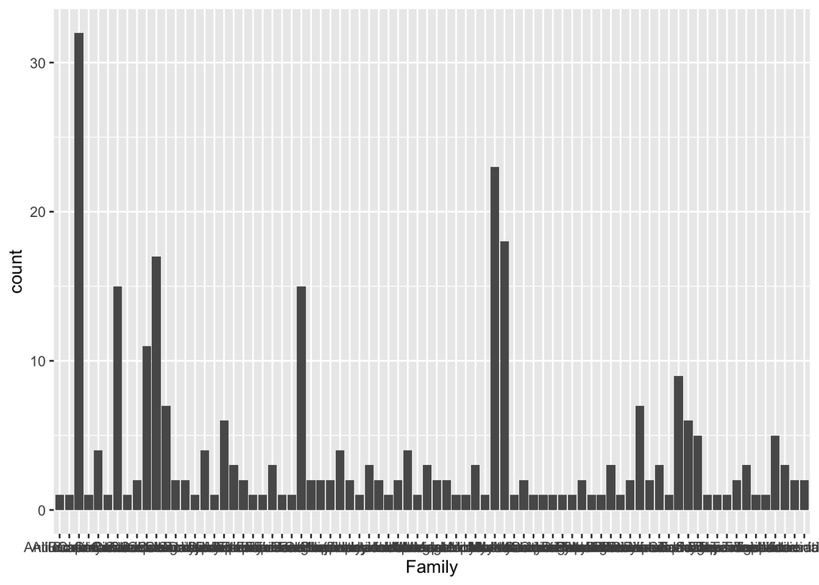

```r
pantheria_anage <- read.csv("pantheria_anage_joined.csv")
view(pantheria_anage)

pantheria_anage %>%
  ggplot() +
  geom_bar(
    mapping = aes(x= Family)
  )
```

```r
pantheria_anage %>%
  group_by(Family) %>%
  summarize(count = n())
```

```
## # A tibble: 78 × 2
##    Family         count
##    <chr>          <int>
##  1 Ailuridae          1
##  2 Antilocapridae     1
##  3 Bovidae           32
##  4 Burramyidae        1
##  5 Callitrichidae     4
##  6 Camelidae          1
##  7 Canidae           15
##  8 Castoridae         1
##  9 Caviidae           2
## 10 Cebidae           11
## # ℹ 68 more rows
```

In the dataset, “pantheria_anage_joined.csv”, the family “Bovidae” is most well-represented, with 32 entries (species) in this category. In contrast, many families are only represented by one entry.

## Task 2: Describe a continuous variable

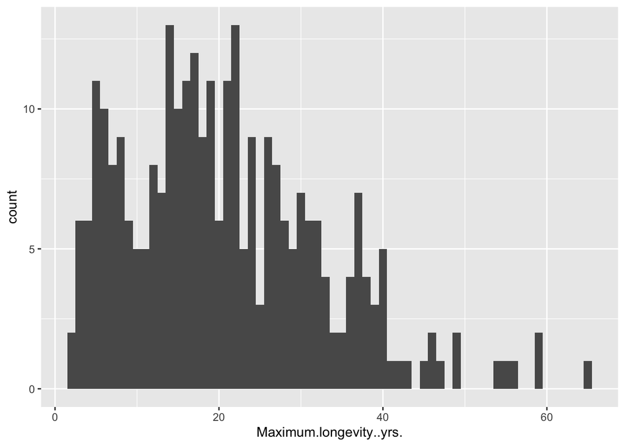

```r
pantheria_anage %>%
  ggplot() +
  geom_histogram(
    mapping = aes(x= Maximum.longevity..yrs.),
    binwidth = 1  )
```

```r
summary(pantheria_anage$Maximum.longevity..yrs.)
```

```
##    Min. 1st Qu.  Median    Mean 3rd Qu.    Max.
##    2.20   12.00   19.00   20.85   28.20   65.50
```

In the dataset, “pantheria_anage_joined.csv”, maximum longevity is not normally distributed, and rather, has a rightward skew. This means that a five number summary is more appropriate here than mean and standard deviation. Across the dataset, the min maximum longevity is 2.2 years, the median maximum longevity is 19 years, and the max maximum longevity is 65.5 years.

## Task 3: Relationship between two variables

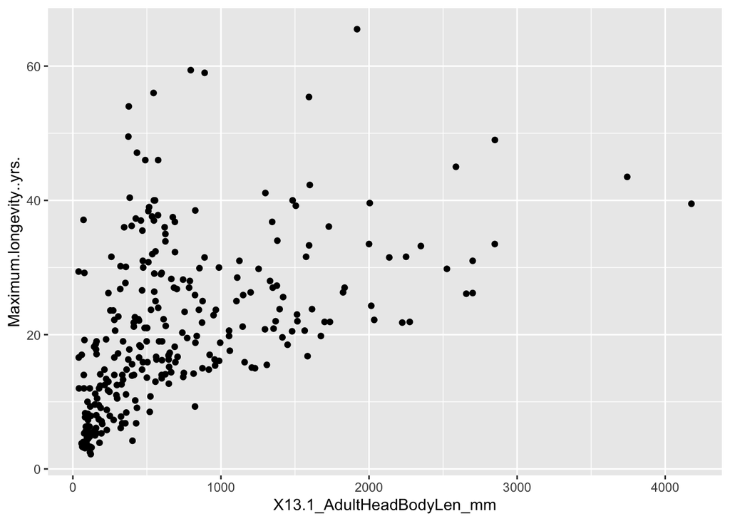

```r
pantheria_anage %>%
  ggplot() +
  geom_point(
    mapping = aes(x = X13.1_AdultHeadBodyLen_mm, y = Maximum.longevity..yrs.)
  )
```

In the dataset, “pantheria_anage_joined.csv”, adult body length including the head is positively correlated with maximum longevity of that species. However, several species exhibit above median maximum longevity (>19 years) despite having a low adult body length. This suggests that in our dataset, body length alone does not account for differences in maximum longevity between species. This may be better understood by looking at additional variables in the dataset, such as body mass, average latitude, etc.

# Part 3: Inferential statistics (Week 5)

## Task 1: State your hypotheses

H₀: Primates and Carnivora have the same distribution of max lifespan

Hₐ: Primates and Carnivora have different distributions of max lifespan

## Task 2: Check normality

```r
library(tidyverse)
library(ggplot2)
agingpantheria <- read.csv("pantheria_anage_joined.csv")
view(agingpantheria)
```

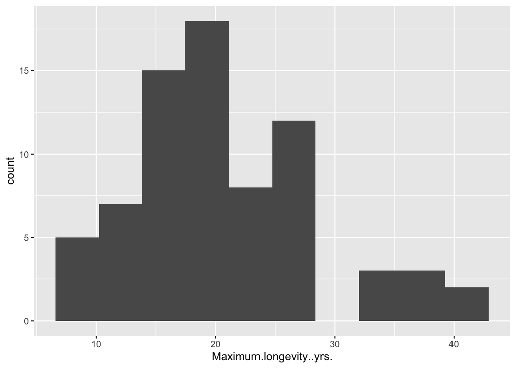

```r
##Carnivora
agingpantheria %>%
  filter(Order == "Carnivora") %>%
  ggplot() +
    geom_histogram(aes(x = Maximum.longevity..yrs.), bins = 10)
```

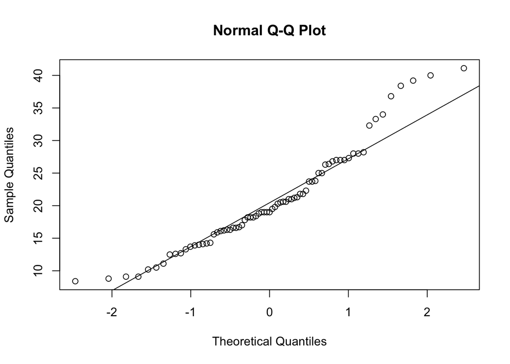

```r
agingpantheria %>%
  filter(Order == "Carnivora") %>%
pull(Maximum.longevity..yrs.) %>%
  qqnorm()
qqline(agingpantheria %>% filter(Order == "Carnivora") %>% pull(Maximum.longevity..yrs.))
```

```r
carnivore_longevity <- agingpantheria$Maximum.longevity..yrs.[agingpantheria$Order == "Carnivora"]
shapiro.test(carnivore_longevity)
```

```
##
##  Shapiro-Wilk normality test
##
## data:  carnivore_longevity
## W = 0.94349, p-value = 0.002623
```

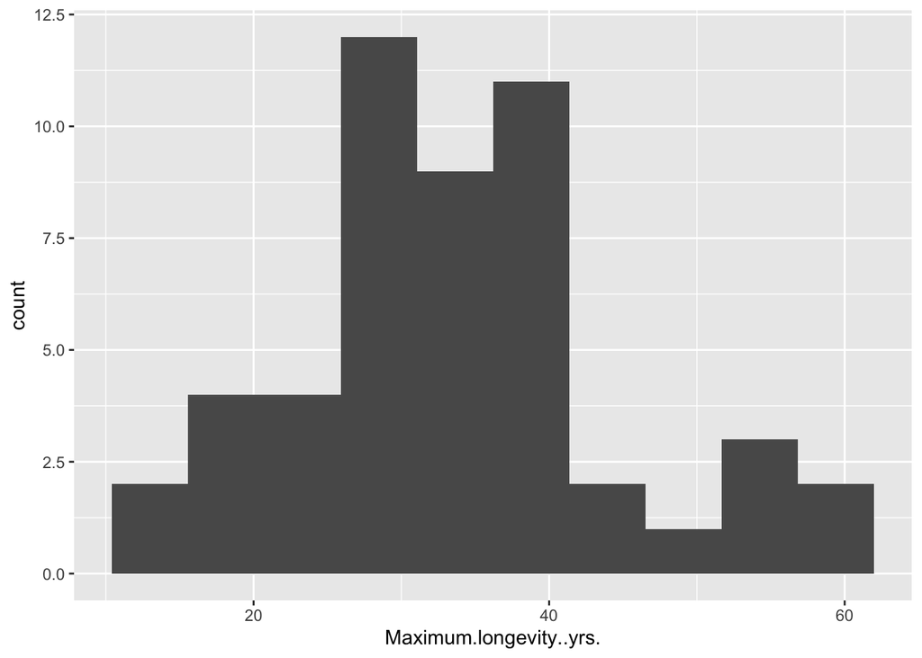

```r
##Primates
agingpantheria %>%
  filter(Order == "Primates") %>%
  ggplot() +
    geom_histogram(aes(x = Maximum.longevity..yrs.), bins = 10)
```

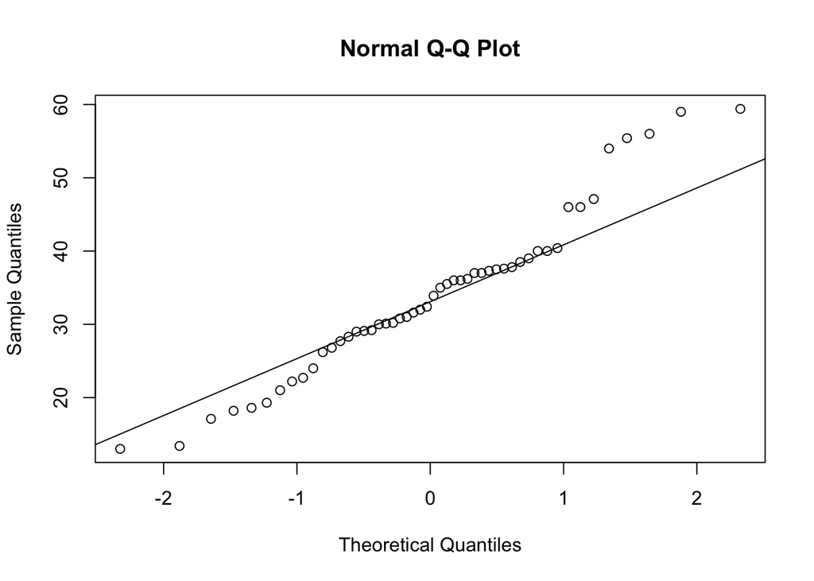

```r
agingpantheria %>%
  filter(Order == "Primates") %>%
pull(Maximum.longevity..yrs.) %>%
  qqnorm()
qqline(agingpantheria %>% filter(Order == "Primates") %>% pull(Maximum.longevity..yrs.))
```

```r
Primate_longevity <- agingpantheria$Maximum.longevity..yrs.[agingpantheria$Order == "Primates"]
shapiro.test(Primate_longevity)
```

```
##
##  Shapiro-Wilk normality test
##
## data:  Primate_longevity
## W = 0.9623, p-value = 0.1109
```

the shapiro-wilk test reveals that while primate longevity does not significantly deviate from normality (p = 0.11), carnivore longevity does (p = 0.0026). Therefore, I cannot confidently use a statistical test that assumes normality. Therefore, I will use the Wilcoxon rank-sum test.

## Task 3: Run the appropriate test

```r
CarnivoresvPrimates <- agingpantheria %>%
  filter(Order %in% c("Carnivora", "Primates"))

wilcox.test(Maximum.longevity..yrs. ~ Order, data = CarnivoresvPrimates, exact = FALSE)
```

```
##
##  Wilcoxon rank sum test with continuity correction
##
## data:  Maximum.longevity..yrs. by Order
## W = 592, p-value = 2.199e-10
## alternative hypothesis: true location shift is not equal to 0
```

```r
median(Primate_longevity)
```

```
## [1] 33.15
```

```r
median(carnivore_longevity)
```

```
## [1] 19
```

To check whether primates are shorter than carnivores in this dataset, I compare the median adult body length of each order.

```r
CarnivoresvPrimates %>%
  group_by(Order) %>%
  summarize(n_species = n(),
            median_body_length_mm = median(X13.1_AdultHeadBodyLen_mm))
```

```
## # A tibble: 2 × 3
##   Order     n_species median_body_length_mm
##   <chr>         <int>                 <dbl>
## 1 Carnivora        73                  625.
## 2 Primates         50                  495.
```

## Task 4: Written conclusion

# Part 4: Regression (Week 6)

```r
library(tidyverse)
library(ggplot2)
agingpantheria <- read.csv("pantheria_anage_joined.csv")
view(agingpantheria)
```

## Task 1: Identify your outcome variable

I have chosen to use maximum longevity as my outcome variable, which is a continuous variable. Since it is a continuous variable, I have chosen to use linear regression.

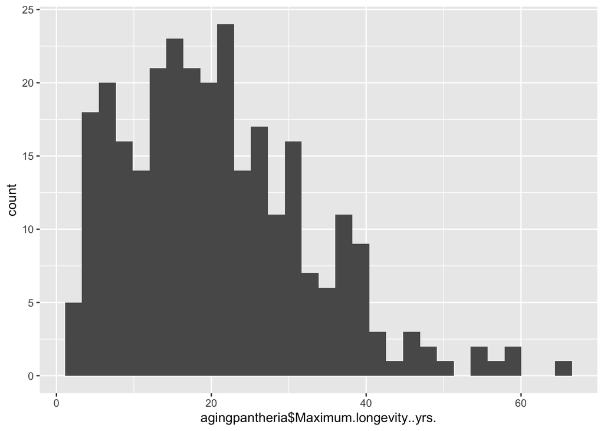

```r
##MaxLongev
  ggplot() +
    geom_histogram(aes(x = agingpantheria$Maximum.longevity..yrs.), bins = 30)
```

## Task 2: Fit the model

```r
# choosing carnivora as reference order since it is the largest/most well-represented in the dataset
agingpantheria$Order <- relevel(as.factor(agingpantheria$Order), ref = "Carnivora")

# Predict max longevity from adult body length and order
model_multi <- lm(Maximum.longevity..yrs. ~ X13.1_AdultHeadBodyLen_mm + Order, data = agingpantheria)
summary(model_multi)
```

```
##
## Call:
## lm(formula = Maximum.longevity..yrs. ~ X13.1_AdultHeadBodyLen_mm +
##     Order, data = agingpantheria)
##
## Residuals:
##      Min       1Q   Median       3Q      Max
## -18.3486  -3.6557  -0.5002   2.8138  22.5142
##
## Coefficients:
##                             Estimate Std. Error t value Pr(>|t|)
## (Intercept)                13.439053   1.077712  12.470  < 2e-16 ***
## X13.1_AdultHeadBodyLen_mm   0.009957   0.001012   9.840  < 2e-16 ***
## OrderAfrosoricida          -2.115328   3.992582  -0.530 0.596682
## OrderArtiodactyla          -5.369058   1.428718  -3.758 0.000211 ***
## OrderChiroptera             5.728815   2.265585   2.529 0.012030 *
## OrderCingulata             -0.596851   3.451339  -0.173 0.862836
## OrderDasyuromorphia        -8.500458   2.881860  -2.950 0.003465 **
## OrderDidelphimorphia      -10.998792   3.983235  -2.761 0.006159 **
## OrderDiprotodontia          1.789280   2.657990   0.673 0.501424
## OrderErinaceomorpha        -4.100607   6.771884  -0.606 0.545340
## OrderHyracoidea            -4.055161   4.814059  -0.842 0.400344
## OrderLagomorpha            -8.877540   6.765910  -1.312 0.190618
## OrderMacroscelidea         -6.668394   4.839254  -1.378 0.169368
## OrderMonotremata           18.657034   4.819383   3.871 0.000136 ***
## OrderPeramelemorphia      -10.362211   4.823863  -2.148 0.032608 *
## OrderPerissodactyla        -0.747739   3.283882  -0.228 0.820055
## OrderPilosa                11.431342   4.810964   2.376 0.018205 *
## OrderPrimates              15.519938   1.255158  12.365  < 2e-16 ***
## OrderProboscidea           32.951051   6.859962   4.803 2.61e-06 ***
## OrderRodentia              -6.362823   1.321126  -4.816 2.46e-06 ***
## OrderScandentia            -2.881139   6.775974  -0.425 0.671035
## OrderSoricomorpha         -11.270523   2.730993  -4.127 4.92e-05 ***
## OrderTubulidentata          3.870312   6.774371   0.571 0.568267
## ---
## Signif. codes:  0 '***' 0.001 '**' 0.01 '*' 0.05 '.' 0.1 ' ' 1
##
## Residual standard error: 6.708 on 266 degrees of freedom
## Multiple R-squared:  0.7155, Adjusted R-squared:  0.692
## F-statistic: 30.41 on 22 and 266 DF,  p-value: < 2.2e-16
```

## Task 3: Interpret your regression coefficients

predictor coefficient 1: X13.1_AdultHeadBodyLen_mm

Adult body length in mm predicting maximum longevity in years. Holding taxonomic Order constant, for every 1 mm increase in adult body length, maximum longevity increases by 0.00996 years (~4 days) on average. This predictor is statistically significant (p < 2e-16)

predictor coefficient 2: OrderPrimates

Taxonomic Order (primates) predicting maximum longevity in years. Holding adult body length constant, primates are expected to live 15.5 years longer on average compared to species in the reference Order, Carnivora. This predictor is statistically significant (p < 2e-16).

## Task 4: Run one diagnostic check

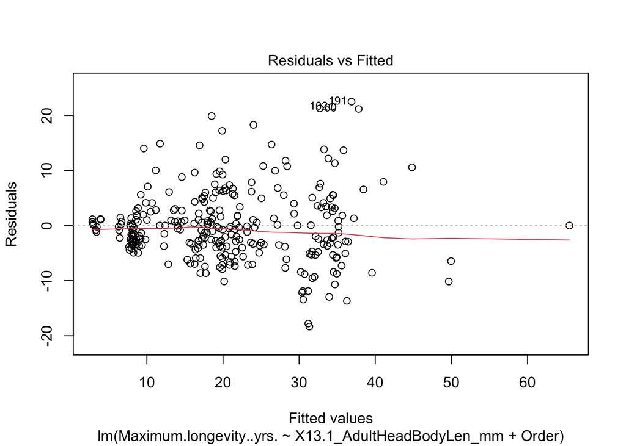

```r
# Residual plots
plot(model_multi, which = 1)   # Residuals vs. Fitted
```

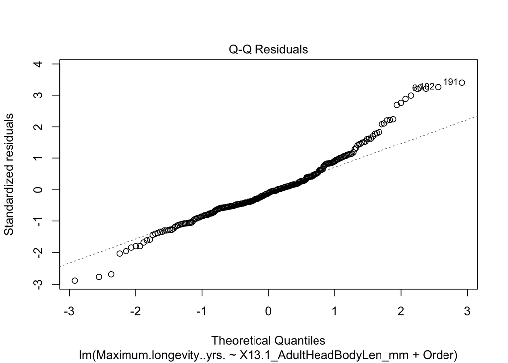

```r
plot(model_multi, which = 2)   # Normal QQ plot
```

residuals vs fitted plot: There is a funnel shape from left to right, indicating uneven spread. Lower fitted values have less vertical spread and as fitted values increase there is more spread. This indicates non-constant variance, violating the constant variance assumption of linear regression. However, since the red line stays relatively flat and close to zero, this suggests a reasonably centered general linear trend.

normal dist in the Q-Q plot: While the central residuals follow the reference line closely, the upper tail curves upward substantially, indicating a heavy right-skew in the residuals and suggesting that the residuals are not normally distributed.

## Written paragraph

I fitted a multiple linear regression model to predict maximum longevity from adult body length and taxonomic order. Key results indicate that adult body length is a statistically significant positive predictor of longevity, with max longevity increasing by about 4 days for every mm increase in body length on average according to the model. Additionally, the taxonomic order Primates exhibits a statistically significant positive effect, living 15.5 years longer on average than the baseline reference order, Carnivora, holding body length constant. Overall, the model explains about 72% of the variation in max longevity in this dataset (R² = 0.72, adjusted R² = 0.69).

however, diagnostic checks indicate notable concerns with the model assumptions. the residuals versus fitted plot shows a funnel-like pattern, indicating heteroscedasticity (increased error at higher predicted values). Also, the normal Q-Q plot shows an upper curved tail, indicating right-skewness and non-normally distributed residuals caused by outlier species with exceptionally long lifespans. These diagnostics suggest that applying a logarithmic transformation to the variables may stabilize variance and help this data meet linear model assumptions.